# Previous HIV Testing among Women Aged 15 to 49 Years in Kenya

An Analysis of the 2014 Kenyan DHS Data

Mengmeng Jia

2026-07-21

# 1 Introduction

HIV testing is an important component of HIV prevention and care. Testing enables individuals to learn their HIV status, access treatment when needed, and make informed decisions about prevention. Although HIV testing services have expanded in many settings, some population groups may still face barriers related to service access, health knowledge, education, social circumstances, or geographic location.

Women aged 15–49 years may encounter HIV testing through antenatal care, reproductive health services, community testing programs, or routine health care. However, opportunities for testing may not be equally distributed. Age, place of residence, educational attainment, and region may influence women’s contact with health services and access to HIV-related information. Knowledge of HIV prevention methods may also be related to previous testing behavior.

This report uses data from the 2014 Kenya Demographic and Health Survey (KDHS) to describe previous HIV testing among women aged 15–49 years. It examines how testing history differed across demographic groups and whether previous testing varied according to knowledge of selected HIV prevention methods.

# 2 Objectives

This report aims to:

1. Describe the proportion of women who had ever been tested for HIV.
2. Compare HIV testing history by age, regions, and educational levels.
3. Examine whether previous HIV testing differed according to knowledge of selected HIV prevention methods.

# 3 Data and methods

The analysis used the women’s individual recode dataset from the 2014 KDHS. Women aged 15–49 years with valid information on previous HIV testing were included.

The main outcome was whether a woman had ever been tested for HIV. Demographic variables included age group, region, residence, educational level, and religion. Two knowledge variables measured whether respondents recognized consistently using condoms and having one faithful uninfected partner as methods of reducing HIV risk.

Counts and percentages were used to describe categorical variables. HIV testing percentages were compared across demographic and knowledge groups. Missing responses to each HIV knowledge item were excluded separately. This was a descriptive analysis, and DHS sampling weights were not applied.

# 4 Results

## 4.1 Characteristics of the study population

The analytic sample included 30,923 women aged 15–49 years. Women aged 15–19 years accounted for the largest proportion of the sample (19.6%), followed by those aged 25–29 years (19.1%). Nearly one-third of participants lived in the Rift Valley region (29.2%), while Nairobi accounted for the smallest regional proportion (3.2%).

Most women lived in rural areas (62.6%). Half of the participants had completed primary education (50.3%). Nearly two-thirds identified as Protestant or another Christian denomination (64.7%). Table 1 summarizes the demographic characteristics of the analytic sample.

Table 1. Characteristics of participants

| Characteristic | Overall, N = 30,923 |
| --- | --- |
| Age group, years |  |
| 15-19 | 6,073 (19.6%) |
| 20-24 | 5,380 (17.4%) |
| 25-29 | 5,894 (19.1%) |
| 30-34 | 4,415 (14.3%) |
| 35-39 | 3,848 (12.4%) |
| 40-44 | 2,971 (9.6%) |
| 45-49 | 2,342 (7.6%) |
| Region |  |
| Nairobi | 999 (3.2%) |
| Central | 3,110 (10.1%) |
| Eastern | 5,228 (16.9%) |
| Coast | 3,874 (12.5%) |
| North Eastern | 1,645 (5.3%) |
| Rift Valley | 9,020 (29.2%) |
| Western | 2,829 (9.1%) |
| Nyanza | 4,218 (13.6%) |
| Residence |  |
| Urban | 11,554 (37.4%) |
| Rural | 19,369 (62.6%) |
| Highest educational level |  |
| No education | 4,132 (13.4%) |
| Primary | 15,543 (50.3%) |
| Secondary | 8,565 (27.7%) |
| Higher | 2,683 (8.7%) |
| Religion |  |
| Protestant/other Christian | 19,987 (64.7%) |
| Roman Catholic | 6,202 (20.1%) |
| Muslim | 4,123 (13.3%) |
| No religion | 502 (1.6%) |
| Other | 72 (0.2%) |
| Missing | 37 |

## 4.2 Overall HIV testing history

Among all participants, 25,682 (83.1%) reported that they had ever been tested for HIV, while 5,241 (16.9%) had never been tested.

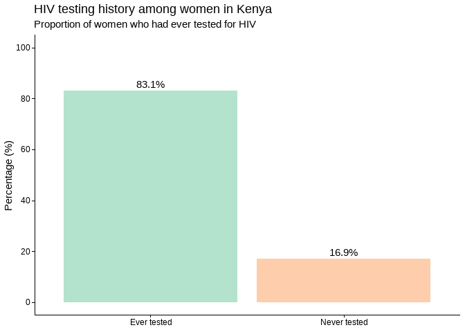

## 4.3 Age distribution by HIV testing history

Women who had previously been tested for HIV were generally older than women who had never been tested. The median age was 29 years (IQR, 23–36 years) among women who had ever been tested, compared with 18 years (IQR, 16–30 years) among women who had never been tested. The median age was therefore 11 years higher among previously tested women. Although the two age distributions overlapped, the distribution among previously tested women was shifted toward older ages.

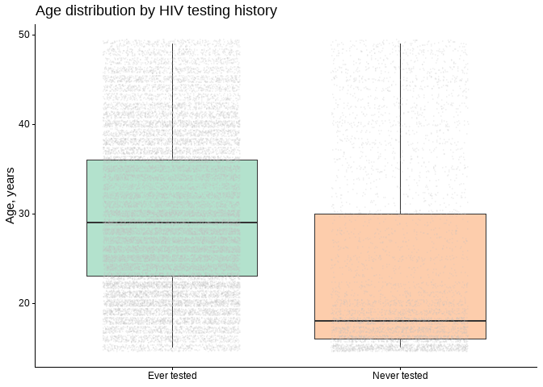

## 4.4 Regional differences in HIV testing

Previous HIV testing varied considerably across regions of Kenya. Nairobi had the highest percentage of women who had ever been tested for HIV (90.2%), whereas North Eastern showed a markedly different pattern. Only 52.5% of women in North Eastern had ever been tested. The difference between Nairobi, the highest-testing region, and North Eastern, the lowest-testing region, was 37.7 percentage points.

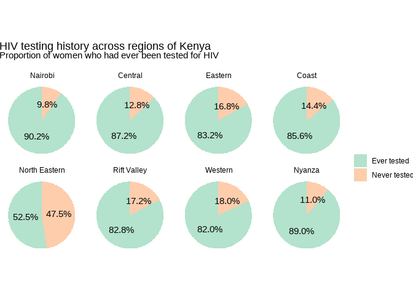

## 4.5 HIV testing by educational level

Previous HIV testing increased with educational attainment. Among women with no education, 71.0% had ever been tested for HIV, compared with 83.9% of women with primary education and 83.9% of women with secondary education. The highest testing percentage was observed among women with higher education, of whom 94.2% had previously received an HIV test.

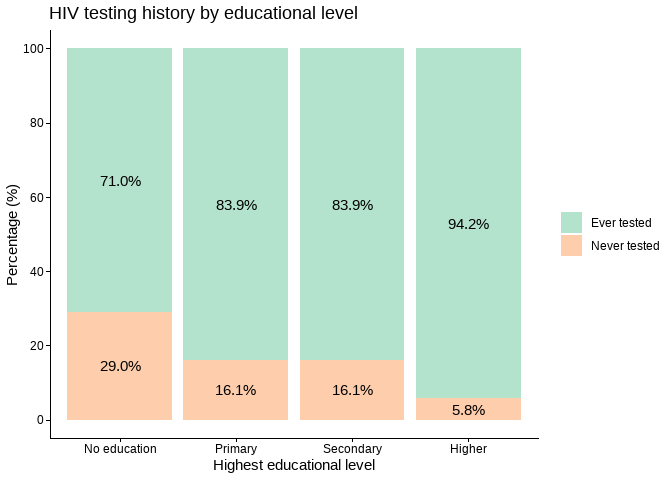

## 4.6 HIV prevention knowledge and previous testing

Previous HIV testing was more common among women who recognized consistent condom use as an HIV prevention method than among those who did not (86.9% vs 77.5%). A similar difference was observed for having one faithful uninfected partner (85.3% vs 72.8%).

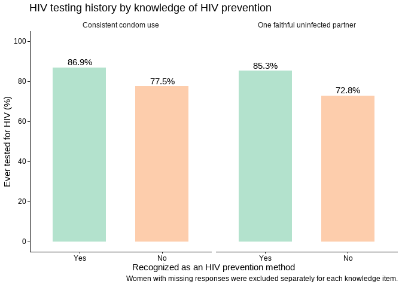

# 5 Limitations

This analysis used self-reported, cross-sectional data and therefore cannot determine the direction or causes of the observed relationships. Survey weights and the complex DHS sampling design were not applied, so the results describe the analytic sample rather than nationally representative estimates.

# 6 Conclusion

Most women in the analytic sample had previously received an HIV test, but testing was not universal. Differences by region, age, education, and HIV prevention knowledge suggest that some groups had lower previous testing levels. The findings demonstrate the value of examining subgroup patterns alongside the overall HIV testing percentage.